# Chap7_7

J.H AHN

2021 12 17

## 7.7 Nonlinear regression

비선형 관계를 모델링하는 가장 간단한 방법은 회귀 모델을 추정하기 전에 forecast variable $y$및 predictor variable $x$를 변환하는 것이다.  
이러한 함수를 적용하면 비선형적이었던 데이터가 선형성을 가지게 된다.  
일반적으로 사용되는 변환은 (자연)로그이다.

log-log 변환은 아래와 같이 수행된다.

$$\log y=\beta_0+\beta_1 \log x +\varepsilon$$

이 모델에서 기울기 $\beta_1$은 $x$의 1% 증가로 인한 $y$의 평균 백분율 변화이다.

다른 유용한 형식도 적용할 수 있다. **log-linear**형식은 forecast variable만 변환하고 **linear-log**형식은 predictor를 변환하여 얻는다.

변수에 로그변환(logarithmic transformation)을 할 때는 모든 값이 0보다 커야한다.  
변수 $x$에 0이 포함된 경우 $log(x+1)$을 사용해야 한다. 즉 변수값에 1을 더한 다음 로그를 취해야 한다. 이러한 방법은 로그변화을 하면서 0의 값을 가질 때 발생할 수 있는 문제를 피하게 해 준다. 또한 1을 더해줌으로써 0을 로그변화해도 여전히 0으로 남아있어 scale로 인한 문제가 발생할 수 있는 것도 방지할 수 있다.

단순히 데이터를 변환하는 것이 적절하지 않고 더 가공이 필요한 경우도 있다.

$$y=f(x) +\varepsilon$$

여기서 $f$는 비선형 함수이다.  
일반적인 (선형) 회귀는 $f(x)=\beta_{0} + \beta_{1} x$ 꼴로 나타낼 수 있다.  
뒤에서 볼 비선형 회귀 방법을 통해 로그변환이나 다른 변화과 비교해서 좀 더 유연한 형태의 비선형 함수를 만들 것이다.

그 중 가장 간단한 방법 중 하나는 $f$를 조각내어 선형으로 만드는 것이다.  
즉 $f$의 기울기가 변할 수 있는 점을 찾고 (이 점을 노트knots라고 한다.) $x_{1,t}$로 둔 다음 $x_{2,t}$를 대입하여 만들 수 있다.

$$\begin{align*}
x_{2,t} = (x-c)_+ &= \left\{
\begin{array}{ll}
0 & \text{if } x < c\\
x-c & \text{if } x \ge c.
\end{array}\right.
\end{align*}$$

$(x-c)_+$ 표기법은 양수이면 $(x-c)$가 되고 그렇지 않으면 0이 된다는 것을 의미한다.  
이렇게 하면 기울기가 점 $c$에서 바뀌게 된다.  
위 방법에 추가 변수를 두면 기울기가 더 바뀌게 만들 수도 있다.

이러한 방식으로 구성된 조각별 선형관계(Piecewise linear relationships)는 회귀 스플라인의 특별한 케이스이다. 일반적으로 선형 회귀 스플라인은 아래의 방식으로 얻을 수 있다.

$$x_{1}= x \quad x_{2} = (x-c_{1})_+ \quad\dots\quad x_{k} = (x-c_{k-1})_+$$

$c_{1},\dots,c_{k-1}$은 노트(knots, 선이 굽어지는 점)이다. 노트의 숫자$(k-1)$와 어느 위치를 지정해야 하는지는 어렵고 다소 임의적일 수 있다. 일부 자동 선택 알고리즘이 있긴하지만 잘 사용하지는 않는다.

### Forecasting with a nonlinear trend

Chap7_4에서 $x=t$로 설정하여 시계열 데이터를 선형 추세로 적합하는 것을 소개했었다.  
비선형 추세를 적합하는 가장 간단한 방법은 2차 또는 고차의 추세를 사용하는 것이다.

$$x_{1,t} =t,\quad x_{2,t}=t^2,\quad \dots.$$

그러나 2차 또는 고차 추세를 예측에 사용하는 것은 권장하지 않는다.  
이런 방법으로 외삽(extrapolated)하게 되면 예측 결과가 비현실적이 되기 때문이다.

더 나은 방법은 위에서 소개한 선형구간을 조각내어 사용하는 것이다.  
여러 개의 선형 추세로 구성된 비선형 추세로 보면, 추세가 변화하는 시점을 $\tau$라 두고, $x=t$, $c=\tau$로 바꾸면 모델에 아래와 같이 predictor를 넣을 수 있다.

$$\begin{align*}
x_{1,t} & = t \\
x_{2,t} &= (t-\tau)_+ = \left\{
\begin{array}{ll}
0 & \text{if } t < \tau\\
t-\tau & \text{if } t \ge \tau
\end{array}\right.
\end{align*}$$

만약 $x_{1,t}$, $x_{2,t}$의 계수가 $\beta_{1}$, $\beta_{2}$이면, $\beta_{1}$은 시간 $\tau$전의 추세의 기울기가 되고, 시간 $\tau$후의 선의 기울기는 $\beta_{1} + \beta_{2}$로 주어진다.  
추가적인 기울기 변화를 주기 위해서는 $(t-\tau)_+$형식의 변수를 추가하면 된다. 여기서 $\tau$는 추세의 기울기가 바뀌는 점 “knots”를 의미한다.

### Example: Boston marathon winning times

보스톤 마라톤 우승기록(남자) 데이터를 이용하여 추세를 모델링 해 볼 것이다.  
우선 남자들의 데이터를 추출하고 우승기록을 숫자형식으로 바꿀 것이다.  
코스길이가 1924년에 24.5마일에서 26.2마일로 늘어나서 우승기록이 크게 뛰었다.  
그래서 데이터는 1924년 이후 데이터만 가지고 만들 것이다.

```r
boston_men <-
    boston_marathon %>%
    filter(Year >= 1924) %>%
    filter(Event == "Men's open division") %>%
    mutate(Minutes = as.numeric(Time/60))
```

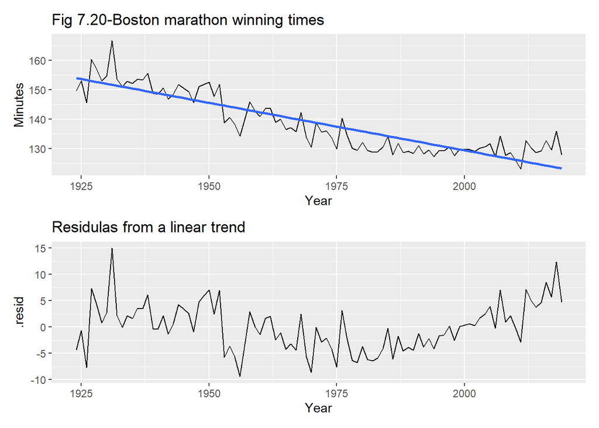

```r
library(patchwork)

p1 <-
    boston_men %>%
    ggplot(aes(Year, Minutes)) +
    geom_line() +
    geom_smooth(method = "lm", se = FALSE) +
    labs(title = "Fig 7.20-Boston marathon winning times")

p2 <-
    boston_men %>%
    model(TSLM(Minutes ~ Year)) %>%
    residuals() %>%
    ggplot(aes(Year, .resid)) +
    geom_line() +
    labs(title = "Residulas from a linear trend")

p1 / p2
```

지수추세(exponential trend - log-linear regression과 동일한 효과)를 주기위해서 아래와 같이 $y$를 변환하여 모델을 만들 수 있다.

$$\log y_t=\beta_0+\beta_1 t +\varepsilon_t.$$

fitted된 지수추세와 예측은 Fig 7.21에 보여진다.  
비록 지수 추세가 데이터에 잘 적합한 것처럼 보이지 않지만 좀 더 선형적인 추세를 가지는 것을 볼 수 있다. 아마도 우승기록이 미래에 감소하는 추세가 고정된 선형 비율로 감소하는 것보다 시간이 지남에 따라 감소 추세가 줄어들 것이라고 추정하는 것이 좀 더 합리적인 예측이라고 볼 수 있다.

우승기록 plot은 세가지 다른 주기를 보여준다.  
약 1950년까지는 우승시간에 많은 변동이 있었으나 크게 감소하지는 않았었다.  
1950년이후에는 시간이 확실히 줄어들었고, 1980년 이후에는 거의 변화가 없다가 최근에는 도리어 상승하는 추세를 보인다.

이러한 주기적인 움직임을 잡아내기 위해서 1950년과 1980년에 knot를 설정한다.  
여기서 knots를 어떻게 주느냐에 따라 예측 모델에 악영향을 미치는 overfitting이 될 수도 있기 때문에 주의해야 한다.

```r
fit_trends <-
    boston_men %>%
    model(
        linear = TSLM(Minutes ~ trend()),
        exponential = TSLM(log(Minutes) ~ trend()),
        piecewise = TSLM(Minutes ~ trend(knots = c(1950, 1980)))
    )

fitted(fit_trends)
```

```
## # A tsibble: 288 x 4 [1Y]
## # Key:       Event, .model [3]
##    Event               .model  Year .fitted
##    <fct>               <chr>  <int>   <dbl>
##  1 Men's open division linear  1924    154.
##  2 Men's open division linear  1925    154.
##  3 Men's open division linear  1926    153.
##  4 Men's open division linear  1927    153.
##  5 Men's open division linear  1928    153.
##  6 Men's open division linear  1929    152.
##  7 Men's open division linear  1930    152.
##  8 Men's open division linear  1931    152.
##  9 Men's open division linear  1932    151.
## 10 Men's open division linear  1933    151.
## # ... with 278 more rows
```

```r
fc_trends <- fit_trends %>% forecast(h = 10)

fc_trends
```

```
## # A fable: 30 x 5 [1Y]
## # Key:     Event, .model [3]
##    Event               .model  Year    Minutes .mean
##    <fct>               <chr>  <dbl>     <dist> <dbl>
##  1 Men's open division linear  2020 N(123, 22)  123.
##  2 Men's open division linear  2021 N(123, 22)  123.
##  3 Men's open division linear  2022 N(122, 22)  122.
##  4 Men's open division linear  2023 N(122, 22)  122.
##  5 Men's open division linear  2024 N(122, 22)  122.
##  6 Men's open division linear  2025 N(121, 22)  121.
##  7 Men's open division linear  2026 N(121, 22)  121.
##  8 Men's open division linear  2027 N(121, 22)  121.
##  9 Men's open division linear  2028 N(120, 22)  120.
## 10 Men's open division linear  2029 N(120, 22)  120.
## # ... with 20 more rows
```

`stats::fitted()`함수는 모델링 함수에 의해 반환된 object로 부터 fitted value를 반환하는 함수이다.

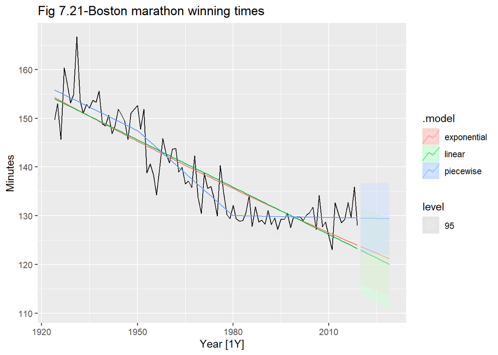

```r
boston_men %>%
    autoplot(Minutes) +
    geom_line(data = fitted(fit_trends),
              aes(y = .fitted, color = .model)) +
    autolayer(fc_trends, alpha = 0.5, level = 95) +
    labs(title = "Fig 7.21-Boston marathon winning times",
         y = "Minutes")
```